# RM 8.5 7DADM — Prediction Intervals and Exceedance Probability

Maddee Wiggins (FlowWest)

2026-09-16

# Objective

`rm85-rf-delta.Rmd` produces a single number per lead day. That is the right point forecast — it is unchanged and still the production model — but it says nothing about how confident it is, and confidence is exactly what a season like 2026 strains. 2026 is the warmest year in the 15-year record: mean 7DADM +2.96°C above the 2011-2025 average, 47% of days at or above the HCP threshold against a historical median of 24%, and 20% of days above anything in the model’s training range.

This document adds a **quantile regression forest** alongside the existing point model, on the same change-from-today target and the same features. Rather than a conditional mean it estimates the whole conditional distribution, which gives two things the point forecast cannot:

- a **prediction interval** — “22.5, 80% likely between 21.8 and 23.3” — so a near-threshold forecast can be read as near-threshold rather than as a hard call;
- an **exceedance probability** — P(7DADM ≥ 20°C) — which replaces the binary flag with a graded risk that can be thresholded to whatever balance of missed exceedances and false alarms the HCP response actually warrants.

The point forecast is deliberately left alone. This document compares the quantile forest’s median against the saved point model and recommends which to use for the headline number, but it does not replace `rm85_rf_7dadm_delta_lead*.rds`.

**One methodological trap worth naming:** a quantile forest’s in-sample interval coverage is ~100%, because each training row lands in its own leaf. Coverage is therefore only ever evaluated below on held-out data — the chronological test split and the real 2026 hindcast — never in-sample.

```r
month_start     <- 5
month_end       <- 10
lead_days_vec   <- c(1:7)
ntree           <- 500
test_frac       <- 0.20
trend_window    <- 5
threshold_7dadm <- 20.0

# Nominal central interval. 80% is the operational default here: wide
# enough to be honest at long leads, narrow enough to be actionable.
interval_lo <- 0.10
interval_hi <- 0.90

# Fine grid used to invert the conditional distribution into an exceedance
# probability; also supplies the median and interval bounds.
q_grid <- seq(0.01, 0.99, by = 0.01)

rm85_logger_file <- "WC85 Rimrock bottom 2026-08-13 09_52_44 PDT.xlsx"

lead_colors <- setNames(colorRampPalette(c("#185FA5", "#4E9F50", "#C93312"))(length(lead_days_vec)),
                        as.character(lead_days_vec))
```

# Data & feature construction

Identical to `rm85-rf-delta.Rmd` — same dynamical.org weather source, same run-date-relative joins, same trajectory summaries and RM 8.5 trend features.

```r
rm85_7dadm <- rm_8_5_historical |>
  mutate(date = as.Date(date)) |> filter(statistic == "7DADM") |>
  select(date, rm_8_5_7dadm = temperature)

rm85_tmax <- rm_8_5_historical |>
  mutate(date = as.Date(date)) |> filter(statistic == "max") |>
  select(date, rm_8_5_tmax = temperature)

cp_7dadm <- camp_polk_temperature_historical |>
  mutate(date = as.Date(date)) |> filter(statistic == "7DADM") |>
  select(date, cp_7dadm = temperature)

cp_tmax <- camp_polk_temperature_historical |>
  mutate(date = as.Date(date)) |> filter(statistic == "max") |>
  select(date, cp_tmax = temperature)

cp_flow <- camp_polk_flow_historical |>
  mutate(date = as.Date(date)) |> filter(statistic == "mean") |>
  select(date, cp_flow_mean = flow_cfs)

# Packaged snapshot of data-raw/dynamical_gfs_air_temp_historical.csv. Extend
# the CSV with data-raw/pull_dynamical_forecasts.py, then re-knit the
# dynamical.org chunk in data-raw/pull-historical-data.Rmd to refresh this.
dyn_raw <- dynamical_gfs_forecasts
```

```r
get_forecast_dyn <- function(lead_k) {
  dyn_raw |> filter(lead_days == lead_k) |>
    select(valid_date, variable, value) |>
    pivot_wider(names_from = variable, values_from = value) |>
    rename(date = valid_date, air_max = temperature_2m_max,
           air_min = temperature_2m_min, cloud_pct = cloud_cover_mean)
}

get_forecast_trajectory_dyn <- function(lead_k) {
  reduce(map(seq_len(lead_k), function(k) {
    get_forecast_dyn(k) |> mutate(run_date = date - k) |>
      transmute(run_date,
        !!paste0("air_max_d", k) := air_max,
        !!paste0("air_min_d", k) := air_min,
        !!paste0("cloud_d",   k) := cloud_pct,
        !!paste0("julian_d",  k) := yday(date))
  }), full_join, by = "run_date") |> arrange(run_date)
}

add_trajectory_summaries <- function(df, lead_k) {
  air_max_cols <- as.matrix(df[, paste0("air_max_d", 1:lead_k), drop = FALSE])
  air_min_cols <- as.matrix(df[, paste0("air_min_d", 1:lead_k), drop = FALSE])
  df$traj_air_max_max  <- apply(air_max_cols, 1, max)
  df$traj_air_max_mean <- apply(air_max_cols, 1, mean)
  df$traj_air_min_mean <- apply(air_min_cols, 1, mean)
  df$traj_warming      <- air_max_cols[, lead_k] - air_max_cols[, 1]
  df
}

build_df_dyn <- function(lead_k) {
  fcst_traj <- get_forecast_trajectory_dyn(lead_k) |>
    mutate(date = run_date + lead_k) |> select(-run_date)

  joined <- rm85_7dadm |>
    left_join(cp_flow  |> mutate(date = date + lead_k), by = "date") |>
    left_join(cp_7dadm |> mutate(date = date + lead_k), by = "date") |>
    left_join(cp_tmax  |> mutate(date = date + lead_k), by = "date") |>
    left_join(fcst_traj, by = "date") |>
    left_join(cp_flow  |> mutate(date = date + lead_k + 1)            |> rename(cp_flow_m1  = cp_flow_mean), by = "date") |>
    left_join(cp_flow  |> mutate(date = date + lead_k + trend_window) |> rename(cp_flow_mw  = cp_flow_mean), by = "date") |>
    left_join(cp_7dadm |> mutate(date = date + lead_k + 1)            |> rename(cp_7dadm_m1 = cp_7dadm),     by = "date") |>
    left_join(cp_7dadm |> mutate(date = date + lead_k + trend_window) |> rename(cp_7dadm_mw = cp_7dadm),     by = "date") |>
    left_join(rm85_7dadm |> mutate(date = date + lead_k)                |> rename(dadm_m0 = rm_8_5_7dadm), by = "date") |>
    left_join(rm85_tmax  |> mutate(date = date + lead_k)                |> rename(tmax_m0 = rm_8_5_tmax),  by = "date") |>
    left_join(rm85_7dadm |> mutate(date = date + lead_k + trend_window) |> rename(dadm_mw = rm_8_5_7dadm), by = "date") |>
    left_join(rm85_tmax  |> mutate(date = date + lead_k + trend_window) |> rename(tmax_mw = rm_8_5_tmax),  by = "date") |>
    mutate(
      cp_flow_trend  = (cp_flow_m1  - cp_flow_mw)  / (trend_window - 1),
      cp_7dadm_trend = (cp_7dadm_m1 - cp_7dadm_mw) / (trend_window - 1),
      dadm_trend     = (dadm_m0 - dadm_mw) / trend_window,
      tmax_trend     = (tmax_m0 - tmax_mw) / trend_window,
      month = month(date)
    ) |>
    filter(month >= month_start, month <= month_end) |>
    drop_na() |> distinct(date, .keep_all = TRUE) |> arrange(date)

  add_trajectory_summaries(joined, lead_k)
}

get_model_features <- function(lead_k) {
  c("cp_flow_mean", "cp_7dadm", "cp_tmax", "cp_flow_trend", "cp_7dadm_trend",
    paste0("air_max_d", 1:lead_k), paste0("air_min_d", 1:lead_k),
    paste0("cloud_d", 1:lead_k), paste0("julian_d", 1:lead_k),
    "dadm_m0", "tmax_m0", "dadm_trend", "tmax_trend",
    "traj_air_max_max", "traj_air_max_mean", "traj_air_min_mean", "traj_warming")
}

split_chronological <- function(df, p = test_frac) {
  df <- df |> arrange(date); n <- nrow(df); n_test <- floor(n * p)
  list(train = df[seq_len(n - n_test), ], test = df[seq(n - n_test + 1, n), ])
}

# Quantile regression forest on the same change-from-today target. Because
# adding dadm_m0 is a monotone shift, quantiles of the change map directly
# onto quantiles of the 7DADM — no re-derivation needed.
fit_qrf_delta <- function(train_df, features, seed = 42) {
  d <- train_df[, features, drop = FALSE]
  d$delta_7dadm <- train_df$rm_8_5_7dadm - train_df$dadm_m0
  ranger(delta_7dadm ~ ., data = d, num.trees = ntree,
         mtry = max(1, floor(length(features) / 3)),
         quantreg = TRUE, seed = seed)
}

# Returns the full quantile grid in 7DADM space (dadm_m0 added back).
predict_quantiles <- function(model, newdata, quantiles = q_grid) {
  q <- predict(model, newdata, type = "quantiles", quantiles = quantiles)$predictions
  sweep(q, 1, newdata$dadm_m0, "+")
}

# P(7DADM >= threshold), read off the predicted quantile grid: the share of
# the conditional distribution sitting above the threshold.
exceedance_prob <- function(qmat, threshold = threshold_7dadm) {
  rowMeans(qmat >= threshold)
}

rmse <- function(pred, obs) sqrt(mean((pred - obs)^2))
```

# Fit the quantile forests

```r
dyn_dfs <- map(lead_days_vec, build_df_dyn)
names(dyn_dfs) <- as.character(lead_days_vec)

dyn_splits <- map(lead_days_vec, function(k) split_chronological(dyn_dfs[[as.character(k)]]))
names(dyn_splits) <- as.character(lead_days_vec)

models_qrf <- map(lead_days_vec, function(k) {
  fit_qrf_delta(dyn_splits[[as.character(k)]]$train, get_model_features(k))
})
names(models_qrf) <- as.character(lead_days_vec)

cat("Fitted quantile forests for leads:", paste(lead_days_vec, collapse = ", "), "\n")
```

```
## Fitted quantile forests for leads: 1, 2, 3, 4, 5, 6, 7
```

# Test-period interval performance

Held-out chronological split. **Coverage** is the fraction of observations that actually fell inside the nominal 80% interval — it should land near 0.80. Materially above means the intervals are too wide to be useful; materially below means they are overconfident.

```r
test_q <- map_dfr(lead_days_vec, function(k) {
  te <- dyn_splits[[as.character(k)]]$test
  qm <- predict_quantiles(models_qrf[[as.character(k)]], te)
  tibble(
    lead = k, date = te$date, obs = te$rm_8_5_7dadm,
    median = qm[, which.min(abs(q_grid - 0.50))],
    lo     = qm[, which.min(abs(q_grid - interval_lo))],
    hi     = qm[, which.min(abs(q_grid - interval_hi))]
  )
})

test_q |>
  group_by(lead) |>
  summarise(n = n(),
            coverage_80 = mean(obs >= lo & obs <= hi),
            mean_width  = mean(hi - lo),
            median_rmse = rmse(median, obs), .groups = "drop") |>
  kable(digits = 3,
        col.names = c("Lead (days)", "n", "80% coverage", "Mean width (°C)", "Median RMSE"))
```

| Lead (days) | n | 80% coverage | Mean width (°C) | Median RMSE |
| --- | --- | --- | --- | --- |
| 1 | 134 | 0.881 | 0.745 | 0.232 |
| 2 | 134 | 0.888 | 1.197 | 0.354 |
| 3 | 135 | 0.896 | 1.720 | 0.470 |
| 4 | 135 | 0.911 | 2.229 | 0.598 |
| 5 | 135 | 0.948 | 2.722 | 0.744 |
| 6 | 135 | 0.941 | 3.210 | 0.878 |
| 7 | 135 | 0.956 | 3.663 | 0.961 |

# Real 2026 hindcast

The operationally honest test: real NWS forecasts as inputs, and the warmest season on record as the target.

```r
nws_cached <- read_csv(here("output", "nws-forecasts-log.csv")) |>
  mutate(run_date = as.Date(run_date), forecast_date = as.Date(forecast_date))

rm_8_5_new <- readxl::read_xlsx(here("data-raw", "data-raw", rm85_logger_file)) |>
  janitor::clean_names()

rm_8_5 <- rm_8_5_new |>
  mutate(date = as.Date(lubridate::floor_date(date_time_pdt, "1 day"))) |>
  group_by(date) |>
  summarize(max = max(temperature_c, na.rm = TRUE), .groups = "drop") |>
  mutate(`7DADM` = zoo::rollapply(max, width = 7, FUN = mean, fill = NA, align = "right"))

rm_8_5_wide <- rm_8_5 |> select(date, actual_7dadm_C = `7DADM`, actual_tmax_C = max)

hindcast_run_dates <- nws_cached |>
  distinct(run_date) |> filter(run_date %in% rm_8_5_wide$date) |>
  pull(run_date) |> sort()

pull_start <- min(hindcast_run_dates) - 10
pull_end   <- max(hindcast_run_dates)

cp_flow_hc <- get_owrd_hydro("14076100", pull_start, pull_end, "MDF") |>
  mutate(date = as.Date(parse_date_time(record_date, orders = c("mdy", "mdy HM")))) |>
  rename(cp_flow_mean = mean_daily_flow_cfs) |> select(date, cp_flow_mean) |> arrange(date)

cp_tmax_hc <- get_owrd_hydro("14076100", pull_start, pull_end, "WTEMP15") |>
  mutate(date = as.Date(parse_date_time(record_date, orders = c("mdy", "mdy HM")))) |>
  group_by(date) |>
  summarise(cp_tmax = max(instantaneous_water_temp_c, na.rm = TRUE), .groups = "drop") |> arrange(date)

cp_7dadm_hc <- cp_tmax_hc |> mutate(cp_7dadm = zoo::rollmean(cp_tmax, k = 7, fill = NA, align = "right"))

cp_daily <- cp_flow_hc |> left_join(cp_tmax_hc, by = "date") |>
  left_join(select(cp_7dadm_hc, date, cp_7dadm), by = "date")
```

```r
safe1 <- function(x) if (length(x) == 0) NA_real_ else x

nws_daily <- function(var, target_date, agg_fn, run_date_val) {
  vals <- nws_cached |>
    filter(run_date == run_date_val, variable == var, forecast_date == target_date) |> pull(value)
  if (length(vals) == 0) return(NA_real_)
  agg_fn(vals, na.rm = TRUE)
}

build_hindcast_row <- function(run_date_val, k) {
  cp_today    <- cp_daily    |> filter(date == run_date_val)
  cp_yest     <- cp_daily    |> filter(date == run_date_val - 1)
  cp_trendw   <- cp_daily    |> filter(date == run_date_val - trend_window)
  rm85_today  <- rm_8_5_wide |> filter(date == run_date_val)
  rm85_trendw <- rm_8_5_wide |> filter(date == run_date_val - trend_window)

  traj <- map(1:k, function(d) {
    tibble(
      !!paste0("air_max_d", d) := nws_daily("maxTemperature", run_date_val + d, max,  run_date_val),
      !!paste0("air_min_d", d) := nws_daily("minTemperature", run_date_val + d, min,  run_date_val),
      !!paste0("cloud_d",   d) := nws_daily("skyCover",       run_date_val + d, mean, run_date_val),
      !!paste0("julian_d",  d) := yday(run_date_val + d)
    )
  }) |> bind_cols()

  bind_cols(
    tibble(run_date = run_date_val, forecast_date = run_date_val + k, lead_days = k,
      cp_flow_mean   = safe1(cp_today$cp_flow_mean),
      cp_7dadm       = safe1(cp_today$cp_7dadm),
      cp_tmax        = safe1(cp_today$cp_tmax),
      cp_flow_trend  = (safe1(cp_yest$cp_flow_mean) - safe1(cp_trendw$cp_flow_mean)) / (trend_window - 1),
      cp_7dadm_trend = (safe1(cp_yest$cp_7dadm)     - safe1(cp_trendw$cp_7dadm))     / (trend_window - 1)),
    traj,
    tibble(dadm_m0 = safe1(rm85_today$actual_7dadm_C),
           tmax_m0 = safe1(rm85_today$actual_tmax_C),
           dadm_trend = (safe1(rm85_today$actual_7dadm_C) - safe1(rm85_trendw$actual_7dadm_C)) / trend_window,
           tmax_trend = (safe1(rm85_today$actual_tmax_C)  - safe1(rm85_trendw$actual_tmax_C))  / trend_window)
  )
}

hindcast_grid   <- expand_grid(run_date = hindcast_run_dates, lead_days = lead_days_vec)
hindcast_inputs <- map2_dfr(hindcast_grid$run_date, hindcast_grid$lead_days, build_hindcast_row)

hindcast_by_lead <- map(lead_days_vec, function(k) {
  add_trajectory_summaries(hindcast_inputs |> filter(lead_days == k), k)
})
names(hindcast_by_lead) <- as.character(lead_days_vec)
```

```r
hindcast_q <- map_dfr(lead_days_vec, function(k) {
  rows <- hindcast_by_lead[[as.character(k)]]
  features <- get_model_features(k)
  ok <- complete.cases(rows[, c(features, "dadm_m0"), drop = FALSE])
  if (!any(ok)) return(NULL)
  rows <- rows[ok, , drop = FALSE]

  qm <- predict_quantiles(models_qrf[[as.character(k)]], rows)

  # The existing point model, for a like-for-like comparison of the
  # headline number. Loaded, never modified.
  point_model <- readRDS(here("output", paste0("rm85_rf_7dadm_delta_lead", k, ".rds")))
  point_pred  <- predict(point_model, rows) + rows$dadm_m0

  tibble(
    run_date = rows$run_date, forecast_date = rows$forecast_date, lead_days = k,
    dadm_m0  = rows$dadm_m0,
    point_rf = point_pred,
    median   = qm[, which.min(abs(q_grid - 0.50))],
    lo       = qm[, which.min(abs(q_grid - interval_lo))],
    hi       = qm[, which.min(abs(q_grid - interval_hi))],
    p_exceed = exceedance_prob(qm)
  )
}) |>
  inner_join(rm_8_5_wide, by = c("forecast_date" = "date")) |>
  filter(!is.na(actual_7dadm_C))

cat(sprintf("Forecast/observation pairs available for evaluation: %d\n", nrow(hindcast_q)))
```

```
## Forecast/observation pairs available for evaluation: 616
```

## Interval coverage and width

```r
hindcast_q |>
  group_by(lead_days) |>
  summarise(n = n(),
            coverage_80 = mean(actual_7dadm_C >= lo & actual_7dadm_C <= hi),
            mean_width  = mean(hi - lo), .groups = "drop") |>
  kable(digits = 3, col.names = c("Lead (days)", "n", "80% coverage", "Mean width (°C)"))
```

| Lead (days) | n | 80% coverage | Mean width (°C) |
| --- | --- | --- | --- |
| 1 | 91 | 0.835 | 0.848 |
| 2 | 90 | 0.922 | 1.412 |
| 3 | 89 | 0.933 | 2.154 |
| 4 | 88 | 0.920 | 2.847 |
| 5 | 87 | 0.908 | 3.372 |
| 6 | 86 | 0.930 | 3.976 |
| 7 | 85 | 0.894 | 4.287 |

## Interval calibration

The nominal 80% interval above is **conservative** — it covers the observation more often than 80% of the time, at both the test period and the hindcast. That is a known tendency of quantile regression forests (leaf-level empirical distributions are wider than the true conditional distribution when leaves are small), and it matters operationally: an interval that is honest about being 95% when it claims 80% is simply wider than it needs to be, which makes near-threshold days look less decidable than they are.

The fix is empirical: sweep the nominal level and pick the one that actually delivers 80% coverage. Critically, that choice is made on the **test period** and then validated on the **2026 hindcast** — calibrating and evaluating on the same rows would just be fitting the calibration to its own scoreboard.

```r
nominal_levels <- seq(0.40, 0.95, by = 0.05)

level_indices <- function(L) {
  c(lo = which.min(abs(q_grid - (1 - L) / 2)),
    hi = which.min(abs(q_grid - (1 - (1 - L) / 2))))
}

# --- Step 1: sweep coverage on the TEST PERIOD (calibration set) ---
coverage_sweep_test <- map_dfr(lead_days_vec, function(k) {
  te <- dyn_splits[[as.character(k)]]$test
  qm <- predict_quantiles(models_qrf[[as.character(k)]], te)
  obs <- te$rm_8_5_7dadm
  map_dfr(nominal_levels, function(L) {
    idx <- level_indices(L)
    tibble(lead_days = k, nominal = L,
           empirical_coverage = mean(obs >= qm[, idx["lo"]] & obs <= qm[, idx["hi"]]),
           mean_width = mean(qm[, idx["hi"]] - qm[, idx["lo"]]))
  })
})

coverage_sweep_test |>
  select(lead_days, nominal, empirical_coverage) |>
  pivot_wider(names_from = lead_days, values_from = empirical_coverage, names_prefix = "L") |>
  kable(digits = 3,
        caption = "Test-period empirical coverage by nominal level and lead (target: 0.80)")
```

Test-period empirical coverage by nominal level and lead (target: 0.80)

| nominal | L1 | L2 | L3 | L4 | L5 | L6 | L7 |
| --- | --- | --- | --- | --- | --- | --- | --- |
| 0.40 | 0.493 | 0.455 | 0.481 | 0.519 | 0.519 | 0.489 | 0.504 |
| 0.45 | 0.545 | 0.522 | 0.548 | 0.578 | 0.578 | 0.541 | 0.570 |
| 0.50 | 0.619 | 0.560 | 0.600 | 0.667 | 0.637 | 0.563 | 0.630 |
| 0.55 | 0.649 | 0.597 | 0.674 | 0.726 | 0.726 | 0.659 | 0.711 |
| 0.60 | 0.672 | 0.694 | 0.733 | 0.763 | 0.741 | 0.696 | 0.770 |
| 0.65 | 0.709 | 0.746 | 0.785 | 0.815 | 0.800 | 0.785 | 0.793 |
| 0.70 | 0.776 | 0.776 | 0.830 | 0.859 | 0.874 | 0.830 | 0.844 |
| 0.75 | 0.836 | 0.821 | 0.881 | 0.881 | 0.911 | 0.867 | 0.896 |
| 0.80 | 0.881 | 0.888 | 0.896 | 0.911 | 0.948 | 0.941 | 0.956 |
| 0.85 | 0.933 | 0.955 | 0.956 | 0.956 | 0.985 | 0.985 | 0.993 |
| 0.90 | 0.940 | 0.955 | 0.970 | 0.985 | 0.985 | 1.000 | 1.000 |
| 0.95 | 0.985 | 0.985 | 0.985 | 1.000 | 1.000 | 1.000 | 1.000 |

```r
calibrated <- coverage_sweep_test |>
  group_by(lead_days) |>
  slice_min(abs(empirical_coverage - 0.80), n = 1, with_ties = FALSE) |>
  ungroup() |>
  select(lead_days, calibrated_nominal = nominal,
         test_coverage = empirical_coverage)

# --- Step 2: apply those levels to the 2026 hindcast (validation set) ---
calibration_check <- map_dfr(lead_days_vec, function(k) {
  rows <- hindcast_by_lead[[as.character(k)]]
  features <- get_model_features(k)
  ok <- complete.cases(rows[, c(features, "dadm_m0"), drop = FALSE])
  rows <- rows[ok, , drop = FALSE]
  qm <- predict_quantiles(models_qrf[[as.character(k)]], rows)

  obs <- rows |> select(forecast_date) |>
    left_join(rm_8_5_wide, by = c("forecast_date" = "date")) |> pull(actual_7dadm_C)
  keep <- !is.na(obs); qm <- qm[keep, , drop = FALSE]; obs <- obs[keep]

  L    <- calibrated$calibrated_nominal[calibrated$lead_days == k]
  idx  <- level_indices(L)
  idx8 <- level_indices(0.80)

  tibble(lead_days = k, calibrated_nominal = L,
         hindcast_coverage = mean(obs >= qm[, idx["lo"]] & obs <= qm[, idx["hi"]]),
         calibrated_width  = mean(qm[, idx["hi"]] - qm[, idx["lo"]]),
         nominal80_width   = mean(qm[, idx8["hi"]] - qm[, idx8["lo"]]))
})

calibrated |>
  left_join(calibration_check, by = c("lead_days", "calibrated_nominal")) |>
  mutate(width_saved = nominal80_width - calibrated_width) |>
  kable(digits = 3,
        col.names = c("Lead (days)", "Calibrated level", "Test coverage",
                      "2026 coverage (validation)", "Calibrated width (°C)",
                      "Nominal-80% width (°C)", "Width saved (°C)"))
```

| Lead (days) | Calibrated level | Test coverage | 2026 coverage (validation) | Calibrated width (°C) | Nominal-80% width (°C) | Width saved (°C) |
| --- | --- | --- | --- | --- | --- | --- |
| 1 | 0.70 | 0.776 | 0.780 | 0.675 | 0.848 | 0.173 |
| 2 | 0.75 | 0.821 | 0.878 | 1.260 | 1.412 | 0.153 |
| 3 | 0.65 | 0.785 | 0.775 | 1.530 | 2.154 | 0.624 |
| 4 | 0.65 | 0.815 | 0.773 | 2.042 | 2.847 | 0.805 |
| 5 | 0.65 | 0.800 | 0.793 | 2.419 | 3.372 | 0.953 |
| 6 | 0.65 | 0.785 | 0.814 | 2.846 | 3.976 | 1.130 |
| 7 | 0.65 | 0.793 | 0.835 | 3.136 | 4.287 | 1.151 |

The calibrated level is chosen on the test period; the “2026 coverage” column is the out-of-sample check that it still lands near 0.80 on a year the calibration never saw. The saved models are unchanged — this is purely a post-processing choice about which quantiles to read off them.

## Point forecast: quantile median vs. the existing model

The saved point model stays in production unless the median clearly beats it here.

```r
hindcast_q |>
  group_by(lead_days) |>
  summarise(
    n = n(),
    `RF point bias`  = mean(point_rf - actual_7dadm_C),
    `RF point RMSE`  = rmse(point_rf, actual_7dadm_C),
    `QRF median bias`= mean(median - actual_7dadm_C),
    `QRF median RMSE`= rmse(median, actual_7dadm_C),
    .groups = "drop") |>
  kable(digits = 3)
```

| lead_days | n | RF point bias | RF point RMSE | QRF median bias | QRF median RMSE |
| --- | --- | --- | --- | --- | --- |
| 1 | 91 | -0.054 | 0.271 | -0.052 | 0.277 |
| 2 | 90 | -0.039 | 0.408 | -0.030 | 0.406 |
| 3 | 89 | -0.042 | 0.541 | -0.045 | 0.552 |
| 4 | 88 | -0.062 | 0.748 | -0.111 | 0.725 |
| 5 | 87 | -0.113 | 0.889 | -0.149 | 0.903 |
| 6 | 86 | -0.108 | 1.009 | -0.181 | 1.012 |
| 7 | 85 | -0.205 | 1.012 | -0.264 | 1.024 |

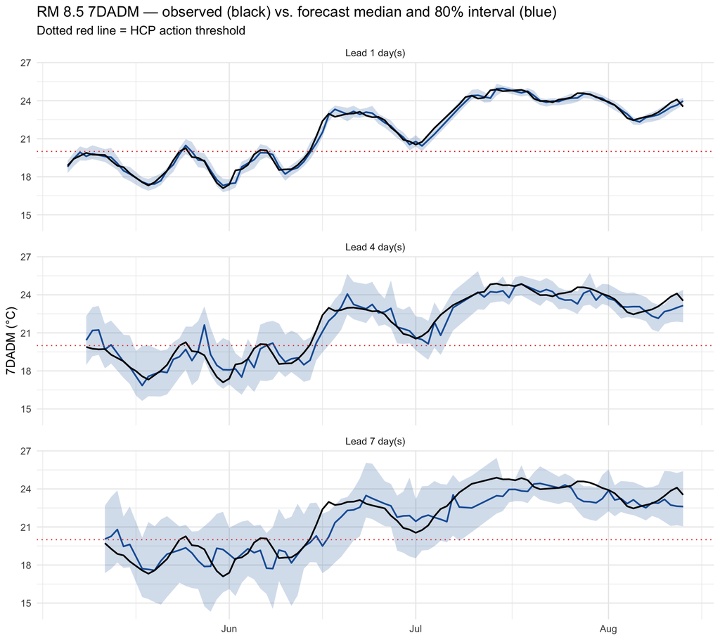

```r
hindcast_q |>
  filter(lead_days %in% c(1, 4, 7)) |>
  mutate(lead_label = paste("Lead", lead_days, "day(s)")) |>
  ggplot(aes(x = forecast_date)) +
  geom_ribbon(aes(ymin = lo, ymax = hi), fill = "#185FA5", alpha = 0.20) +
  geom_line(aes(y = median), color = "#185FA5", linewidth = 0.7) +
  geom_line(aes(y = actual_7dadm_C), color = "black", linewidth = 0.7) +
  geom_hline(yintercept = threshold_7dadm, linetype = "dotted", color = "#E24B4A") +
  facet_wrap(~lead_label, ncol = 1) +
  labs(title = "RM 8.5 7DADM — observed (black) vs. forecast median and 80% interval (blue)",
       subtitle = "Dotted red line = HCP action threshold",
       x = NULL, y = "7DADM (°C)") +
  theme_minimal()
```

# Exceedance probability

Instead of a binary flag, each forecast now carries P(7DADM ≥ 20°C). Two things need checking: whether those probabilities are **calibrated** (when the model says 70%, does it happen about 70% of the time?), and what they buy operationally.

```r
reliability <- hindcast_q |>
  mutate(bin = cut(p_exceed, breaks = seq(0, 1, 0.2), include.lowest = TRUE)) |>
  group_by(bin) |>
  summarise(n = n(), mean_predicted = mean(p_exceed),
            observed_frequency = mean(actual_7dadm_C >= threshold_7dadm), .groups = "drop")

reliability |>
  kable(digits = 3,
        col.names = c("Predicted probability bin", "n", "Mean predicted", "Observed frequency"))
```

| Predicted probability bin | n | Mean predicted | Observed frequency |
| --- | --- | --- | --- |
| [0,0.2] | 120 | 0.077 | 0.058 |
| (0.2,0.4] | 71 | 0.279 | 0.141 |
| (0.4,0.6] | 44 | 0.491 | 0.364 |
| (0.6,0.8] | 32 | 0.730 | 0.656 |
| (0.8,1] | 349 | 0.981 | 0.989 |

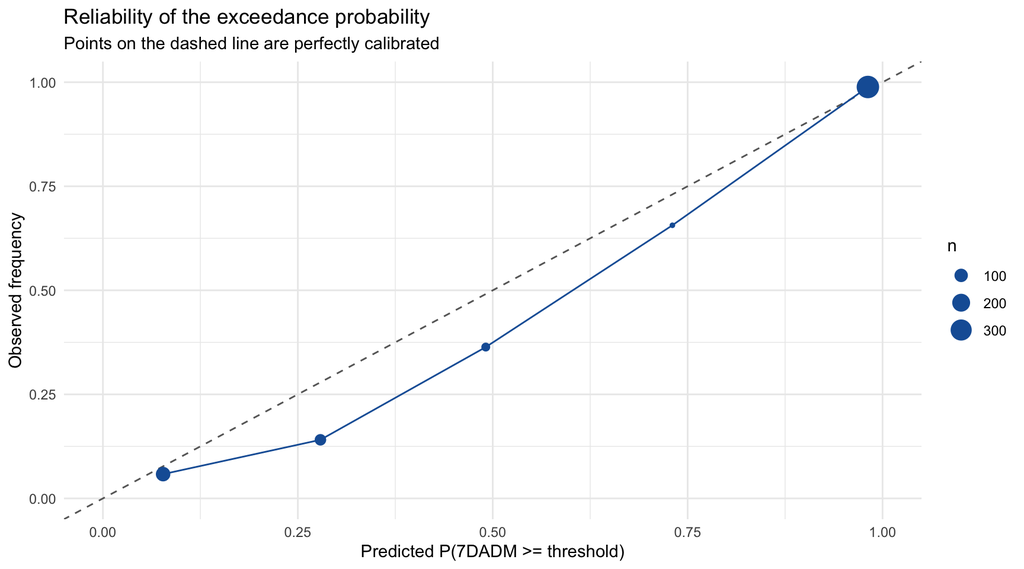

```r
ggplot(reliability, aes(x = mean_predicted, y = observed_frequency)) +
  geom_abline(slope = 1, intercept = 0, linetype = "dashed", color = "#666666") +
  geom_point(aes(size = n), color = "#185FA5") +
  geom_line(color = "#185FA5") +
  scale_x_continuous(limits = c(0, 1)) + scale_y_continuous(limits = c(0, 1)) +
  labs(title = "Reliability of the exceedance probability",
       subtitle = "Points on the dashed line are perfectly calibrated",
       x = "Predicted P(7DADM >= threshold)", y = "Observed frequency", size = "n") +
  theme_minimal()
```

## Choosing an alert threshold

A probability lets the alert cutoff be tuned to how the response is weighted. Missing an exceedance and raising a false alarm are not equally costly, and this table makes the trade explicit rather than fixing it at the model’s own 50/50 point.

```r
map_dfr(seq(0.1, 0.9, by = 0.1), function(p) {
  d <- hindcast_q |> mutate(flag = p_exceed >= p, actual = actual_7dadm_C >= threshold_7dadm)
  tp <- sum(d$flag & d$actual); tn <- sum(!d$flag & !d$actual)
  fp <- sum(d$flag & !d$actual); fn <- sum(!d$flag & d$actual)
  tibble(alert_at = p, flagged = sum(d$flag),
         sensitivity = tp / (tp + fn), specificity = tn / (tn + fp),
         precision = if (tp + fp > 0) tp / (tp + fp) else NA_real_,
         accuracy = (tp + tn) / nrow(d), missed = fn, false_alarms = fp)
}) |>
  kable(digits = 3,
        col.names = c("Alert at P >=", "Days flagged", "Sensitivity", "Specificity",
                      "Precision", "Accuracy", "Missed", "False alarms"))
```

| Alert at P >= | Days flagged | Sensitivity | Specificity | Precision | Accuracy | Missed | False alarms |
| --- | --- | --- | --- | --- | --- | --- | --- |
| 0.1 | 545 | 0.997 | 0.323 | 0.730 | 0.760 | 1 | 147 |
| 0.2 | 496 | 0.982 | 0.521 | 0.790 | 0.820 | 7 | 104 |
| 0.3 | 454 | 0.970 | 0.691 | 0.852 | 0.872 | 12 | 67 |
| 0.4 | 425 | 0.957 | 0.802 | 0.899 | 0.903 | 17 | 43 |
| 0.5 | 401 | 0.935 | 0.871 | 0.930 | 0.912 | 26 | 28 |
| 0.6 | 381 | 0.917 | 0.931 | 0.961 | 0.922 | 33 | 15 |
| 0.7 | 371 | 0.905 | 0.954 | 0.973 | 0.922 | 38 | 10 |
| 0.8 | 349 | 0.865 | 0.982 | 0.989 | 0.906 | 54 | 4 |
| 0.9 | 314 | 0.787 | 1.000 | 1.000 | 0.862 | 85 | 0 |

```r
map_dfr(c(0.3, 0.5), function(p) {
  hindcast_q |>
    mutate(flag = p_exceed >= p, actual = actual_7dadm_C >= threshold_7dadm) |>
    group_by(lead_days) |>
    summarise(alert_at = p, n = n(),
              sensitivity = sum(flag & actual) / max(1, sum(actual)),
              specificity = sum(!flag & !actual) / max(1, sum(!actual)),
              .groups = "drop")
}) |>
  pivot_wider(names_from = alert_at, values_from = c(sensitivity, specificity)) |>
  kable(digits = 3)
```

| lead_days | n | sensitivity_0.3 | sensitivity_0.5 | specificity_0.3 | specificity_0.5 |
| --- | --- | --- | --- | --- | --- |
| 1 | 91 | 1.000 | 0.947 | 0.912 | 1.000 |
| 2 | 90 | 0.982 | 0.965 | 0.818 | 0.909 |
| 3 | 89 | 0.982 | 0.947 | 0.625 | 0.812 |
| 4 | 88 | 0.982 | 0.947 | 0.645 | 0.806 |
| 5 | 87 | 0.947 | 0.930 | 0.633 | 0.800 |
| 6 | 86 | 0.930 | 0.895 | 0.621 | 0.862 |
| 7 | 85 | 0.965 | 0.912 | 0.536 | 0.893 |

# Saved artifacts

```r
walk(lead_days_vec, function(k) {
  saveRDS(models_qrf[[as.character(k)]],
          here("output", paste0("rm85_qrf_7dadm_delta_lead", k, ".rds")))
})

# The calibrated nominal level per lead is part of the model contract — an
# interval read at the wrong level is not an 80% interval. Saved alongside
# so downstream code doesn't have to re-derive it.
calibrated |>
  left_join(calibration_check, by = c("lead_days", "calibrated_nominal")) |>
  select(lead_days, calibrated_nominal, test_coverage, hindcast_coverage) |>
  write_csv(here("output", "rm85_qrf_interval_calibration.csv"))

cat("Quantile forests saved to output/rm85_qrf_7dadm_delta_lead*.rds\n")
```

```
## Quantile forests saved to output/rm85_qrf_7dadm_delta_lead*.rds
```

```r
cat("Interval calibration saved to output/rm85_qrf_interval_calibration.csv\n")
```

```
## Interval calibration saved to output/rm85_qrf_interval_calibration.csv
```

These sit **alongside** `rm85_rf_7dadm_delta_lead*.rds`, which is unchanged and remains the point forecast. Like the point models they are trained on the change from today, so `dadm_m0` must be added back:

```r
qm <- predict(model, newdata, type = "quantiles", quantiles = q_grid)$predictions
qm <- sweep(qm, 1, newdata$dadm_m0, "+")   # now in 7DADM space
p_exceed <- rowMeans(qm >= 20)
```